# US Energy

## Dataset

Our data was taken from eia.gov. [Energy Information Administration](http://eia.gov). EIA provides a wide range of information and data products covering energy production, stocks, demand, imports, exports, and prices. In particular, we focused on energy production relating to renewable energy. This includes Solar, Geothermal, Wind, Hydroelectric, Biomass, Biodiesel, and Ethanol. EIA provides monthly energy reviews, and have been publishing them since 1976, with both annual and monthly data statistics. We downloaded multiple tables and uploaded them to the DS_US_ENERGY account.

## Summary

By using anomaly detection from Oracle Data Miner, we were able to identify multiple months of abnormal growth in energy production. With the current data we have, we were unable to identify why these months exhibited large growth in their respective energy sources. Follow-up investigations on these particular years is required.

This summary lists the years of the anomalous months for generality. The values are in percent and represent the percent growth of the particular energy source in contrast with the previous month.

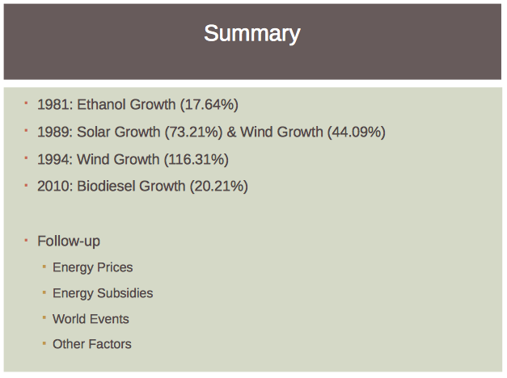

## Analysis

### Oracle Data Miner

The major focus of our analysis was the Anomaly Detection algorithm of Oracle Data Miner. In short, the Anomaly Detection algorithm examines the data given to it, and records 2 values that describes the abnormality of each entry. These 2 values produced by the SVM (Support Vector Machine) are the ANOM_SVM_PRED and ANOM_SVM_PROB.

We also briefly investigated Clustering but were not able to fully grasp the results of the algorithm.

#### Workflow

Our workflow is included in the DataMiner folder. Here is a picture showing our Anomaly Detection Query Data Correction SQL Queries were required to convert Date/Time values into numeric values as well as aggregate the data allowing for the creation of the calculated fields needed by the Anomaly Detection.

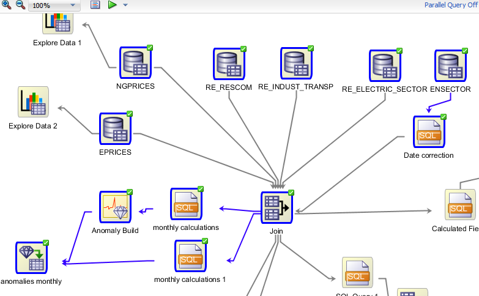

#### SQL Queries

We were able to aggregate energy output from a specific source after using subqueries. We totaled each energy source by adding the output from each sector.

For example: We summed the total solar energy output for that month by adding the residential sector output, industrial output, commercial output, and so forth.

In order to generate useful calculated fields, we used the lag function to calculate percent growth of energy output from the previous month. We then classified growth for each source with a relative range.

```
Each calculation has a raw percent as well as a classified field of [High - , Med - ,Low - , stagnant , Low + , Med + , High +]
```

We used these in our anamoly detection algorithms

### ANOMALY DETECTION

#### ANOM_SVM_PRED

A value of 0 indicates that the entry is anomalous. A value of 1 indicates that the entry is NOT anomalous.

#### ANOM_SVM_PROB

This value indicates the probability that the entry is typical or atypical. The higher the value (as it gets closer to 1) the more anomalous the entry is.

#### Anomaly Detection Result Sample

A small sample picture of the Anomaly Detection Query.

Sorted first by ANOM_SVM_PRED-Ascending(anomalous entries at the top/Value of 0)

Then by ANOM_SVM_PROB-Descending(most anomalous entries at the top/Highest probability)

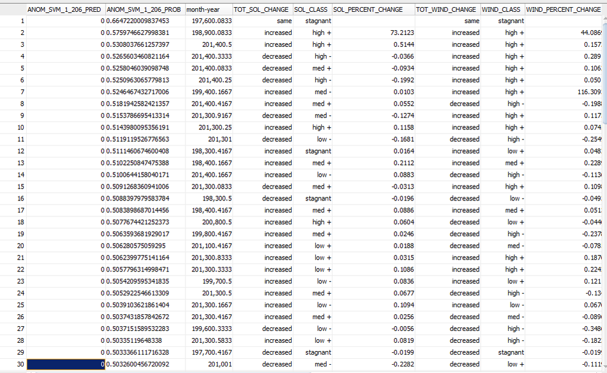

### Tableau

We then extracted this table to an excel file to allow it to be plotted in Tableau.

The table is located in Tableau folder and is named “Anomaly.xlsx”

#### Tableau Representation of Anomalies

In this Tableau representation, each circle represents a MONTH. Notice that in a particular year, there are overlapping circles to represent each month of that year.

The X Axis represents years.

ANOM_SVM_PRED is denoted by color, where RED indicates the month had a value of 0, and is therefore an anomaly.

Green indicates the month is NOT anomalous.

ANOM_SVM_PROB is the Y Axis.

From this representation, we notice 5 anomalous MONTHS in the years 1976, 1981, 1989, 2010, and 2014.

We now decided to look at those particular anomalous months and examine their respective energy production values.

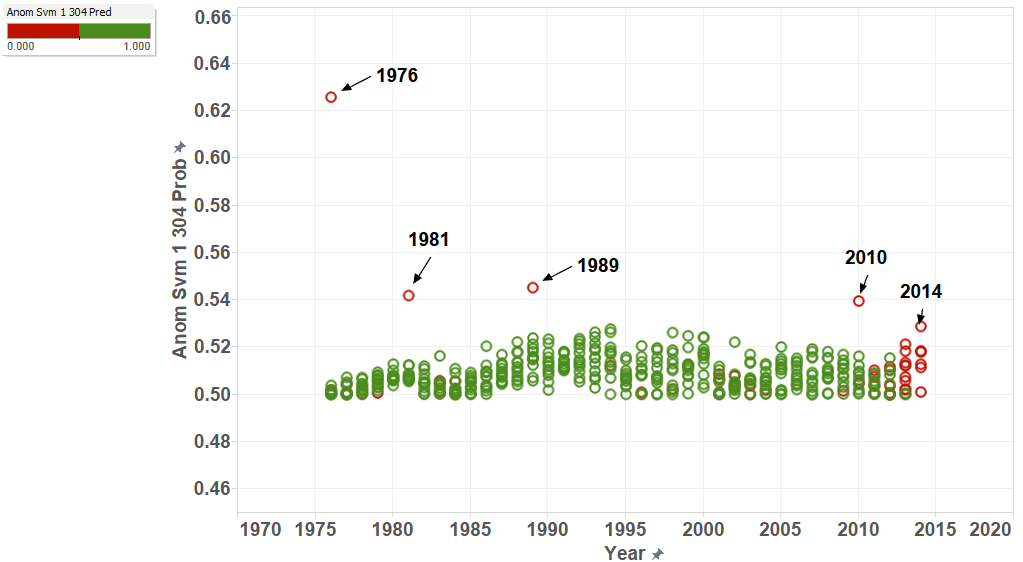

### Anomaly Analysis

We examined each month’s energy production and here are our results.

#### 1976

The reason why 1976 was so high on the SVM’s probability value is that it was the very first entry recorded and displayed unique values for our calculated fields.

It was the only month that displayed stagnant and same values for each energy source.

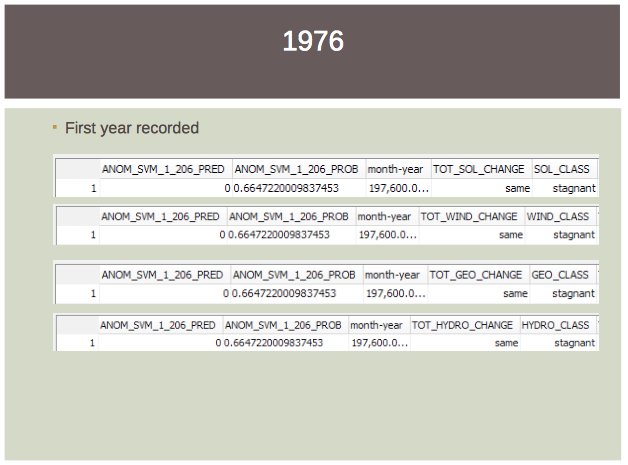

#### 1981

From the picture below, you can see the extremely high percent growth of Ethanol relative to the other energy sources.

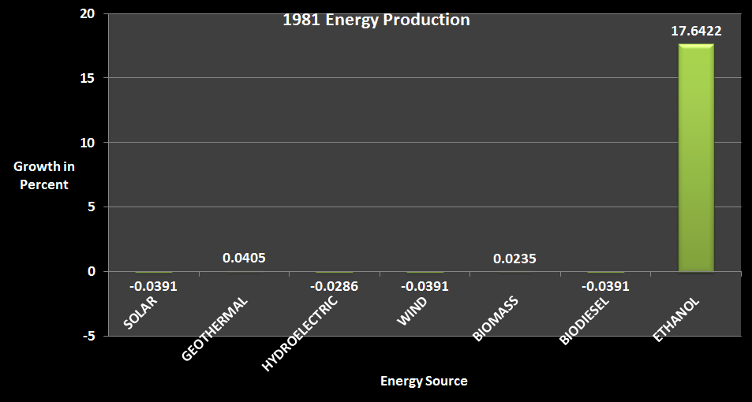

#### 1981 Ethanol Tableau

A Tableau representation of Ethanol Percent Growth (with Anomalies colored) over the years shows that 1981 is most likely anomalous due to Ethanol’s abnormal growth in that one instance.

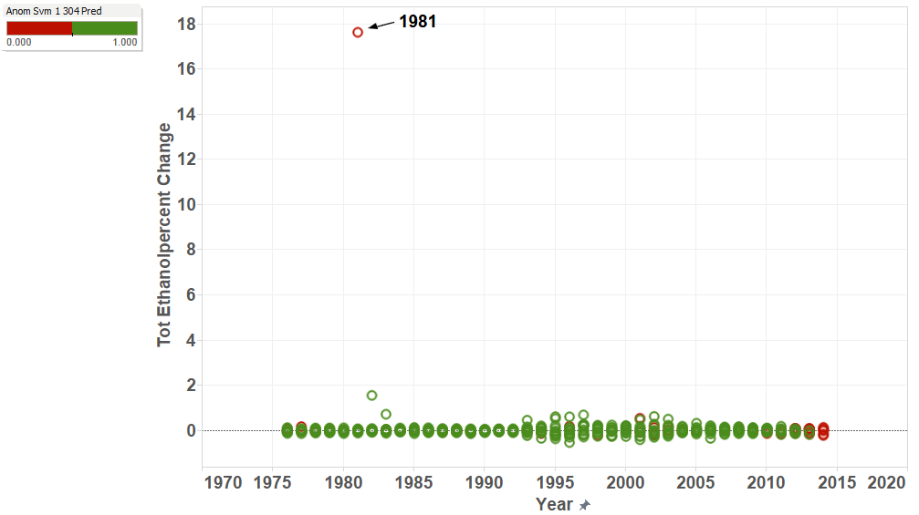

#### 1989

In 1989, examination of energy production of all energy sources shows that there was a large growth in Solar and Wind energy. We now have to examine both Solar and Wind Energy production over the years.

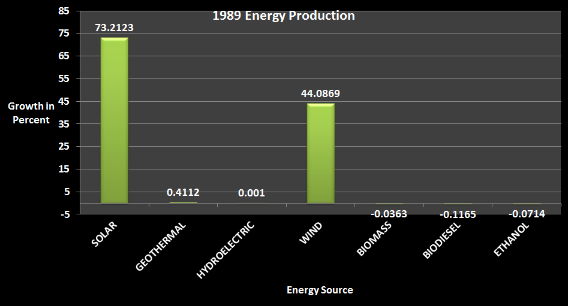

#### 1989 Solar Tableau

As you can see, a plot of Solar Production over the years shows the extremely large growth in 1989.

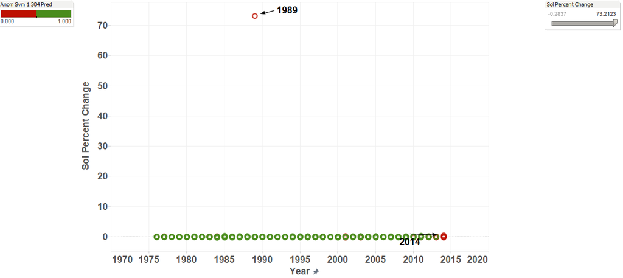

#### 1989 Wind Tableau

As you can see, a plot of Wind Production over the years shows the extremely large growth in 1989.

NOTE: An important point is that there was an even larger growth in 1994.

This will be addressed later, for now it is safe to say that 1989 was considered anomalous due to the large Solar and Wind growth in production.

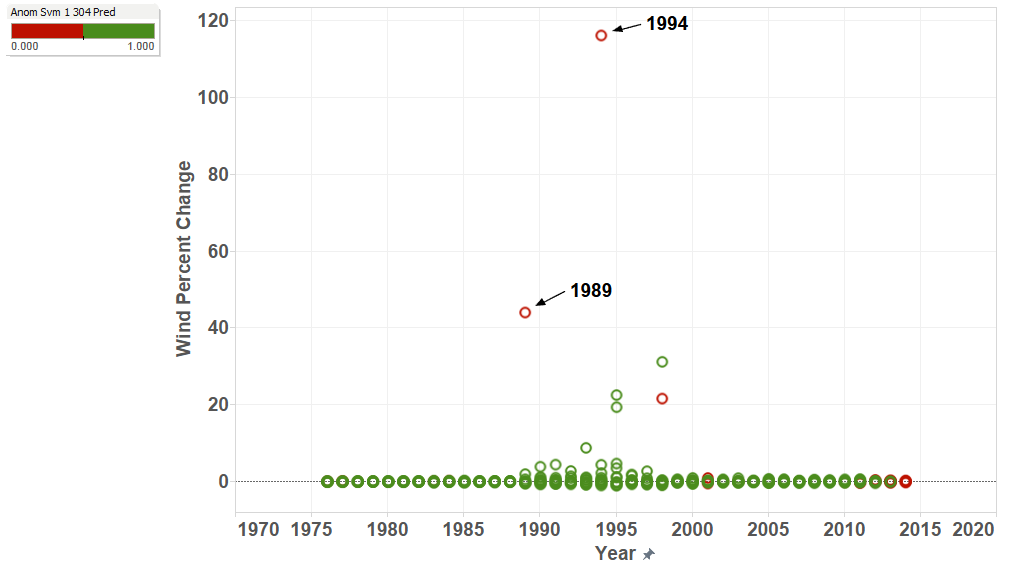

#### 2010

In 2010, examination of energy production of all energy sources shows that there was a large growth in Biodiesel production.

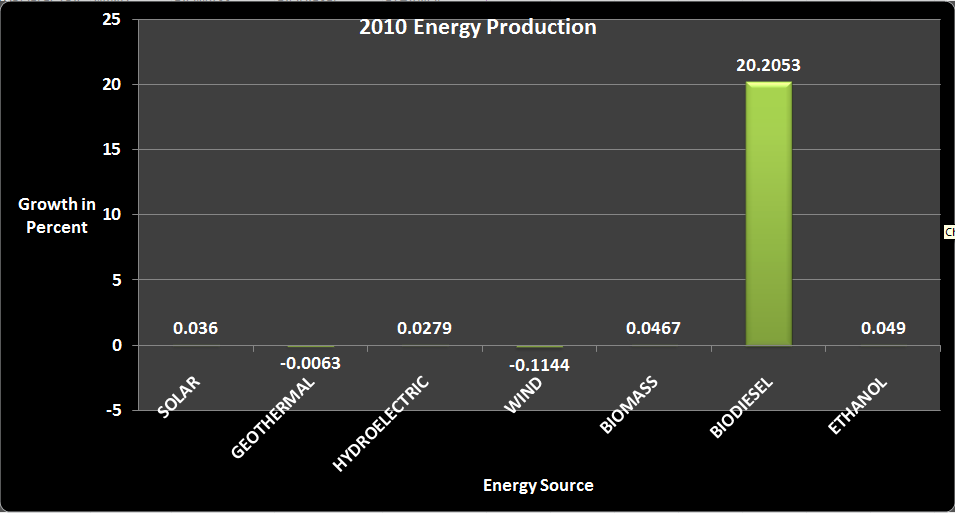

#### 2010 Biodiesel Tableau

Again we look at the Tableau representation of Biodiesel Percent Growth (with Anomalies colored). This shows that 2010 is most likely anomalous due to Biodiesel’s abnormal growth in that particular month.

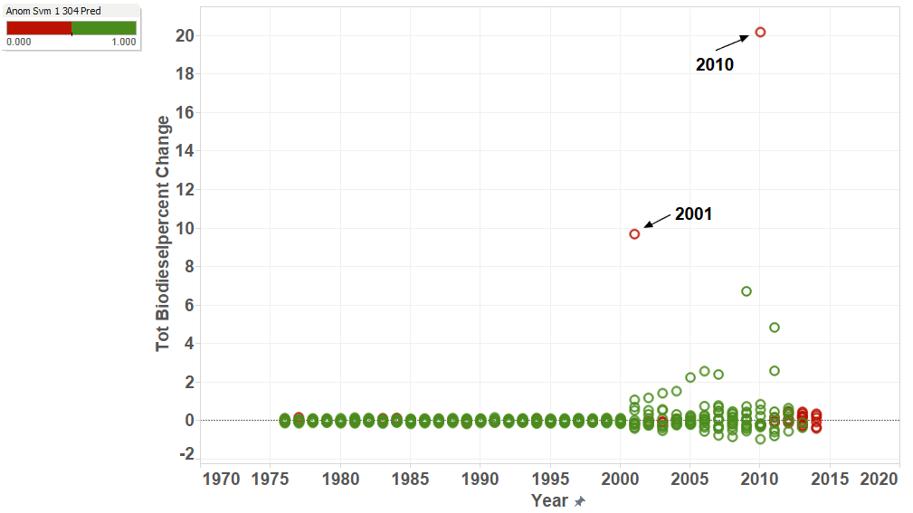

#### 2014

Finally, the last anomaly to examine is 2014. examination of energy production of all energy sources shows that there was a decent growth in Solar and Hydroelectric production.

##### NOTE: However these values are nowhere near as large as our previous growths.

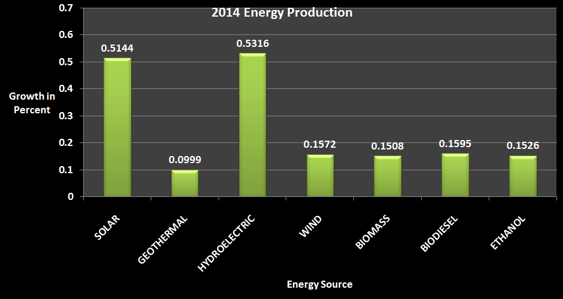

#### 2014 Hydroelectric Tableau

Just like before we look at the Tableau representation of Hydroelectric Percent Growth (with Anomalies colored). This however shows that the growth of Hydroelectric Energy wasn’t necessarily that high in comparison with its other years.

We can conclude that hydroelectric energy growth was not a large factor in the SVM’s decision to deem this month anomalous.

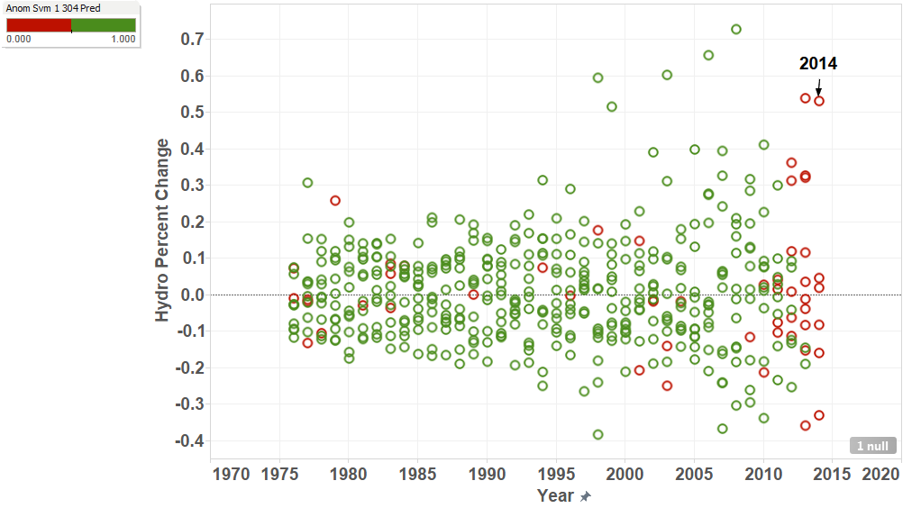

#### 2014 Solar Tableau

Because the Solar Tableau representation is skewed with the extremely large growth in 1989, we filtered out that particular month and examined the rest of the entries.

Once filtered, we can see that 2014 does have a relatively large percent growth in comparison with the other months. This could be why 2014 was considered anomalous by the SVM.

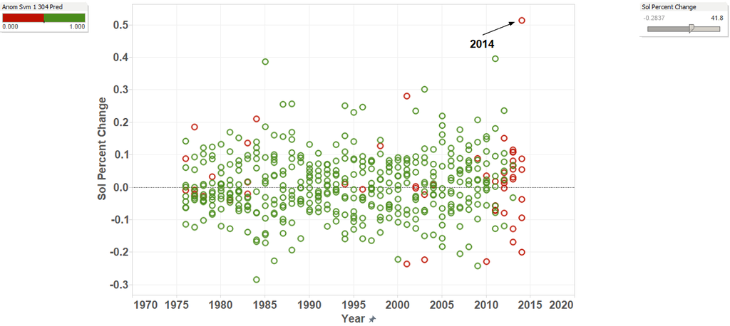

#### Wind Revisited

Going back to Wind Production over the years, we notice that 1994 was anomalous but was not listed in our top 5 anomalous years.

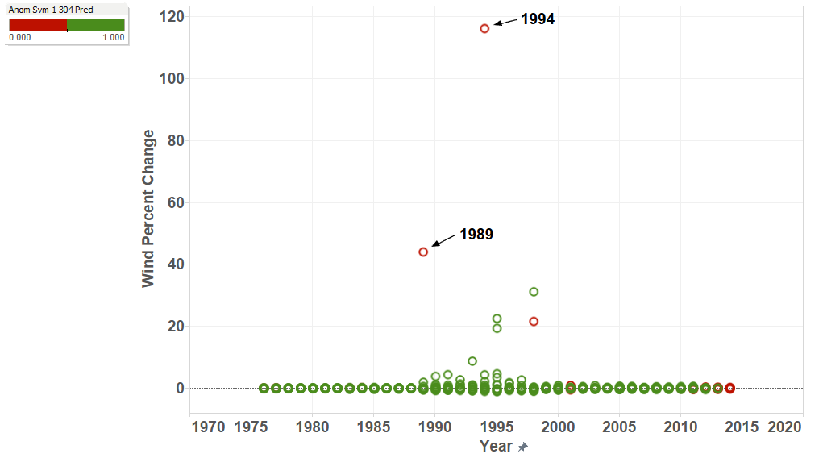

##### NOTE: NO 1994

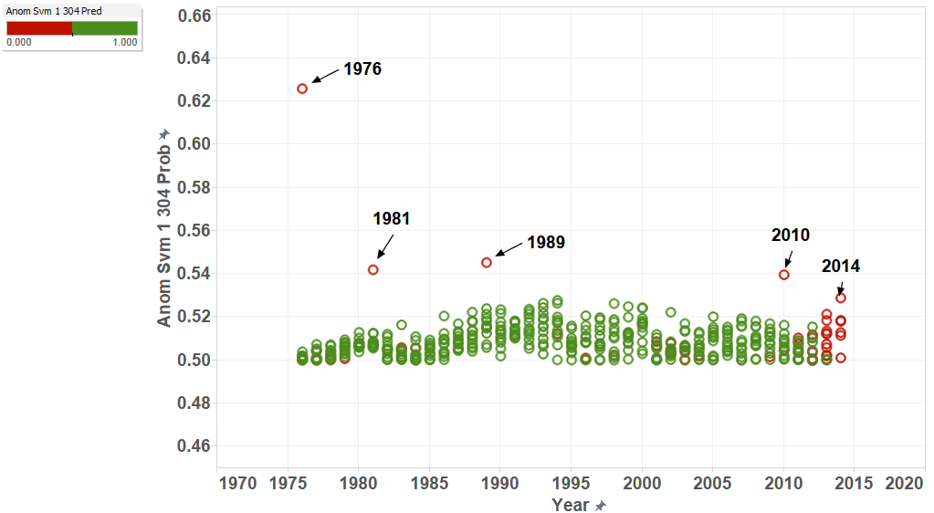

#### 1994

Looking further we can see that Wind growth compared to other energy sources was extremely large but also that this growth is the HIGHEST out of any of the other anomalous months (Previous high was ~70% increase in solar 1989).

This wind percentage growth is 116%!

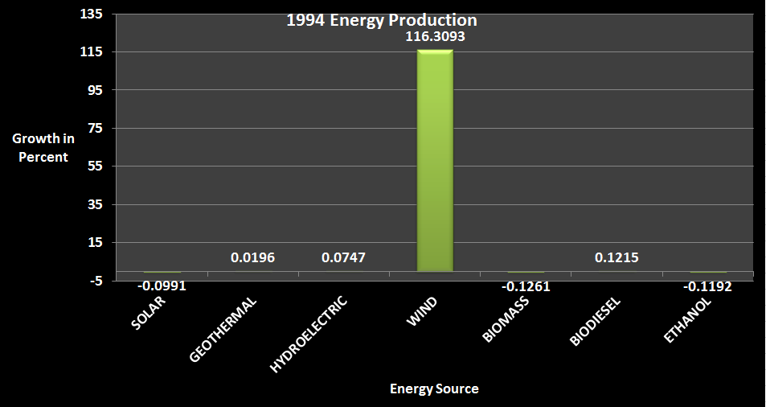

#### 1994 Summary

Although this wind growth was the highest we’ve seen out of any energy source, the SVM did not give the entry a high probability value and was therefore not in the top 5 anomalous months.

### CLUSTERING

We also briefly investigated clustering on our datasets. Here are our results.

#### Clustering Results

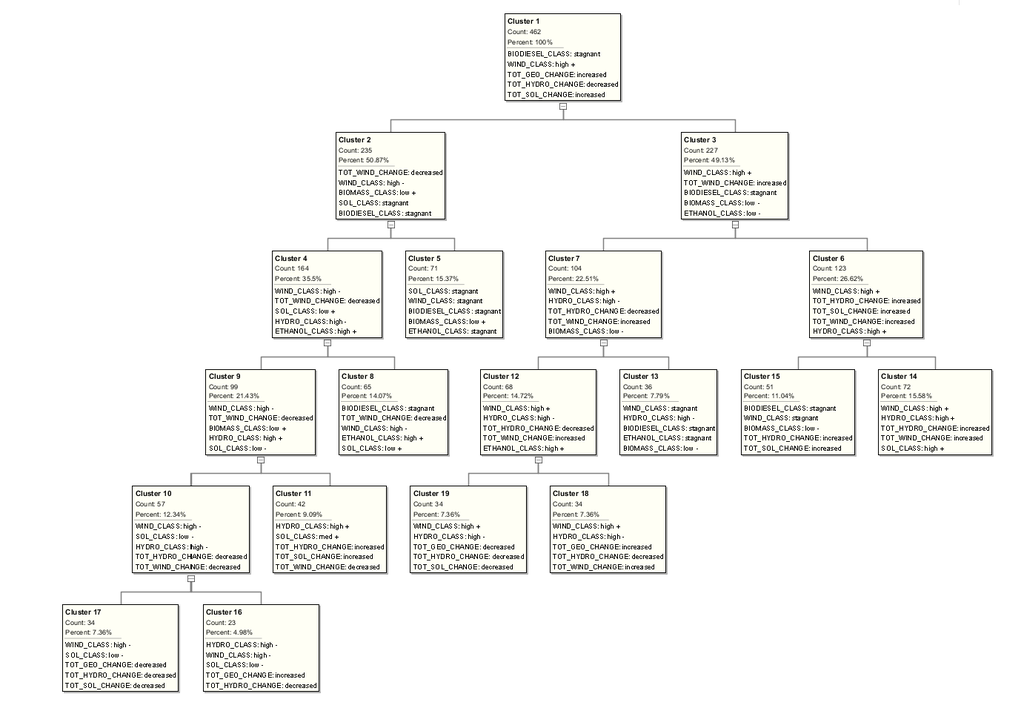

#### Clustering Analysis

Cluster 14

Cluster 15

Cluster 8

We tried to investigate these clusters individually.

We wrote a small program that matched each month in our data to the attributes in each cluster. It goes through the text document containing the data, and parses line by line and matches the attributes per column. If it matches every attribute, it prints out the year and month.

The program is included in the Cluster folder(named cluster.java) along with the input for the program (monthlycluster.txt)

#### Cluster 14

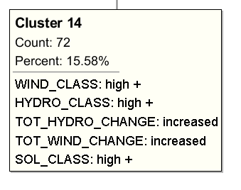

##### Program Output:

Year: 1986 Month: 3

Year: 1989 Month: 1

Year: 1989 Month: 3

Year: 1991 Month: 5

Year: 1993 Month: 3

Year: 1994 Month: 3

Year: 1999 Month: 3

Year: 2001 Month: 3

Year: 2002 Month: 6

Year: 2002 Month: 7

Year: 2003 Month: 6

Year: 2005 Month: 6

Year: 2006 Month: 5

Year: 2007 Month: 3

Year: 2008 Month: 3

Year: 2009 Month: 3

Year: 2012 Month: 3

Year: 2014 Month: 6

##### Cluster 14 Observation

These months shared all of the attributes in the clusters. There are many months not listed here because they do not exactly match every attribute for the cluster. For example, for cluster 14, the clustering algorithm found 72 months that shared some of the attributes found, they do not necessarily possess the exact attributes in this cluster. Thus, when we ran the small program, it only found a small set that matched the attributes in cluster 14. However, we think that matching months are strong representations of the data in that cluster. By “strong representation”, we mean that the months that shared the traits, for example in cluster 14, will largely revolve around the years and months found in our program, namely:

1989: January - March

Early 1990’s: March - May

1999 - 2010: March - July

That is the general trend found in the months that shares the attributes of cluster 14. It seems as if wind, hydro, and solar energy experienced moderate growth from 1989 to present day in the first half of each year if we generalize this trend further.

#### Cluster 15

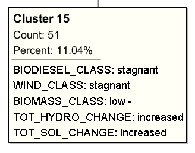

##### Program Output:

Year: 1977 Month: 4

Year: 1977 Month: 9

Year: 1978 Month: 4

Year: 1978 Month: 9

Year: 1979 Month: 4

Year: 1980 Month: 4

Year: 1981 Month: 4

Year: 1981 Month: 11

Year: 1982 Month: 4

Year: 1987 Month: 9

Year: 1988 Month: 9

##### Cluster 15 Observation

Most of the months gathered here were April and September, we’re uncertain as to why these months shared these attributes

#### Cluster 11

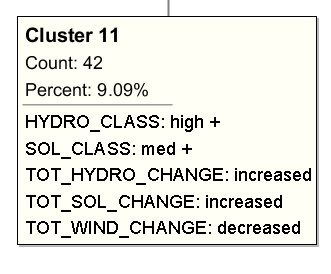

##### Program Output:

Year: 1991 Month: 3

Year: 1992 Month: 3

Year: 1992 Month: 5

Year: 1998 Month: 5

Year: 2000 Month: 3

Year: 2007 Month: 6

Year: 2009 Month: 6

Year: 2010 Month: 6

Year: 2012 Month: 7

Year: 2012 Month: 6

Year: 2013 Month: 5

Year: 2013 Month: 6

##### Cluster 11 Observation

Most of the months gathered were from March to June. Which is primarily the Spring season in the U.S. This could partially explain the increased solar energy production as daylength is steadily increasing from the end of the Winter season and going into Summer season.

#### Cluster 8

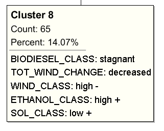

#### Program Output:

Year: 1991 Month: 1

Year: 1992 Month: 1

Year: 1994 Month: 8

Year: 1996 Month: 3

Year: 1997 Month: 3

Year: 1998 Month: 4

Year: 1998 Month: 3

##### Cluster 8 Observation

No generalized trend could be gathered here.

### Summary

Unfortunately, we were unable to explain these large energy growths or why 1994 was not listed higher in the anomalous probability scale.

We tried looking into energy prices and matching these energy growths with any changes but found no correlations.

We also looked at energy subsidies and found no correlation with these growths.

Further investigation needed to explain these growths as well as clustering results.